# Homework 6

Gus Lipkin ~ glipkin6737@floridapoly.edu

> Vacuum pumps are being audited to determine if the process is in control and also capable of meeting the customer specifications. Samples of size n=5 are taken each hour of the day and tested with the data on vacuum recorded. The results of 10 consecutive hours of testing are provided.

```r
library(tidyverse)
library(data.table)
dt <- fread("Homework 6.csv")
dt
```

| Sample | One | Two | Three | Four | Five |
| --- | --- | --- | --- | --- | --- |
| 1 | 15 | 17 | 16 | 17 | 14 |
| 2 | 16 | 16 | 9 | 14 | 15 |
| 3 | 17 | 17 | 15 | 15 | 14 |
| 4 | 18 | 15 | 16 | 16 | 16 |
| 5 | 13 | 15 | 17 | 16 | 19 |
| 6 | 10 | 15 | 11 | 17 | 18 |
| 7 | 15 | 15 | 14 | 14 | 16 |
| 8 | 14 | 13 | 12 | 15 | 14 |
| 9 | 15 | 18 | 18 | 12 | 10 |
| 10 | 12 | 12 | 15 | 15 | 16 |

```r
valueTable <- data.table("SampleSize" = 2:7,
                         "A2" = c(1.88, 1.02, .73, .58, .48, .42),
                         "D3" = c(rep(0, 5), .08),
                         "D4" = c(3.27, 2.57, 2.28, 2.11, 2.00, 1.92),
                         "d2" = c(1.13, 1.69, 2.06, 2.33, 2.53, 2.70))

valueTable <- valueTable[ncol(dt) - 2]
```

## A.

> Find the x and R of each sample and record above.

```r
dt[, c("xBar", "R") := .(rowMeans(dt[,2:ncol(dt)]),
                          do.call(pmax, dt[,2:ncol(dt)]) -
                           do.call(pmin, dt[,2:ncol(dt)]))]
dt
```

| Sample | One | Two | Three | Four | Five | xBar | R |
| --- | --- | --- | --- | --- | --- | --- | --- |
| 1 | 15 | 17 | 16 | 17 | 14 | 15.8 | 3 |
| 2 | 16 | 16 | 9 | 14 | 15 | 14.0 | 7 |
| 3 | 17 | 17 | 15 | 15 | 14 | 15.6 | 3 |
| 4 | 18 | 15 | 16 | 16 | 16 | 16.2 | 3 |
| 5 | 13 | 15 | 17 | 16 | 19 | 16.0 | 6 |
| 6 | 10 | 15 | 11 | 17 | 18 | 14.2 | 8 |
| 7 | 15 | 15 | 14 | 14 | 16 | 14.8 | 2 |
| 8 | 14 | 13 | 12 | 15 | 14 | 13.6 | 3 |
| 9 | 15 | 18 | 18 | 12 | 10 | 14.6 | 8 |
| 10 | 12 | 12 | 15 | 15 | 16 | 14.0 | 4 |

## B

> Find and record the grand mean $\bar{\bar{x}}$ and $\bar{R}$ in the appropriate boxes.

```r
writeLines(paste("The grand mean is:", xBar <- mean(dt$xBar)))
```

```
## The grand mean is: 14.88
```

```r
writeLines(paste("The R is:", R <- mean(dt$R)))
```

```
## The R is: 4.7
```

## C

> Find the UCL and LCL for the $\bar{x}$ chart.

```r
writeLines(paste("The UCL for the x chart is:", xBarUCL <- xBar + (valueTable$A2 * R)))
```

```
## The UCL for the x chart is: 17.606
```

```r
writeLines(paste("The LCL for the x chart is:", xBarLCL <- xBar - (valueTable$A2 * R)))
```

```
## The LCL for the x chart is: 12.154
```

## D

> Find the UCL and LCL for the R chart.

```r
writeLines(paste("The UCL for the R chart is:", RUCL <- valueTable$D4 * R))
```

```
## The UCL for the R chart is: 9.917
```

```r
writeLines(paste("The LCL for the R chart is:", RLCL <- valueTable$D3 * R))
```

```
## The LCL for the R chart is: 0
```

## E

> Sketch out a control chart for the x-bar chart. Is the process in control in terms of the “average” vacuum pressure? ______ Yes or No

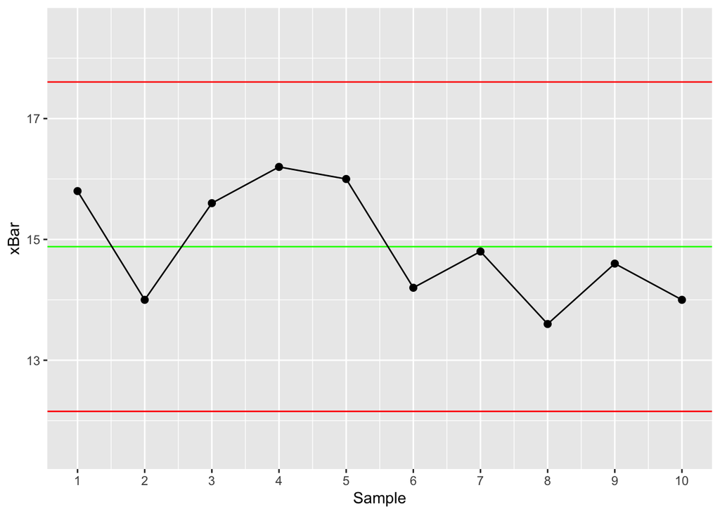

```r
dt %>%
  ggplot() +
  geom_hline(yintercept = xBarLCL, color = "red") +
  geom_hline(yintercept = xBar, color = "green") +
  geom_hline(yintercept = xBarUCL, color = "red") +
  geom_line(aes(x = Sample, y = xBar)) +
  geom_point(aes(x = Sample, y = xBar), size = 2) +
  scale_x_continuous("Sample", 1:nrow(dt)) +
  ylim(c(xBarLCL - (xBarLCL * .05), xBarUCL * 1.05))
```

```r
if(min(dt$xBar) > xBarLCL & max(dt$xBar) < xBarUCL) {
  writeLines("The process is in control in terms of the average.")
} else {
  writeLines("The process is not in control in terms of the average.")
}
```

```
## The process is in control in terms of the average.
```

## F

> Sketch out a control chart for the R chart. Is the process in control in terms of the “variation” in the process? _______ Yes or No

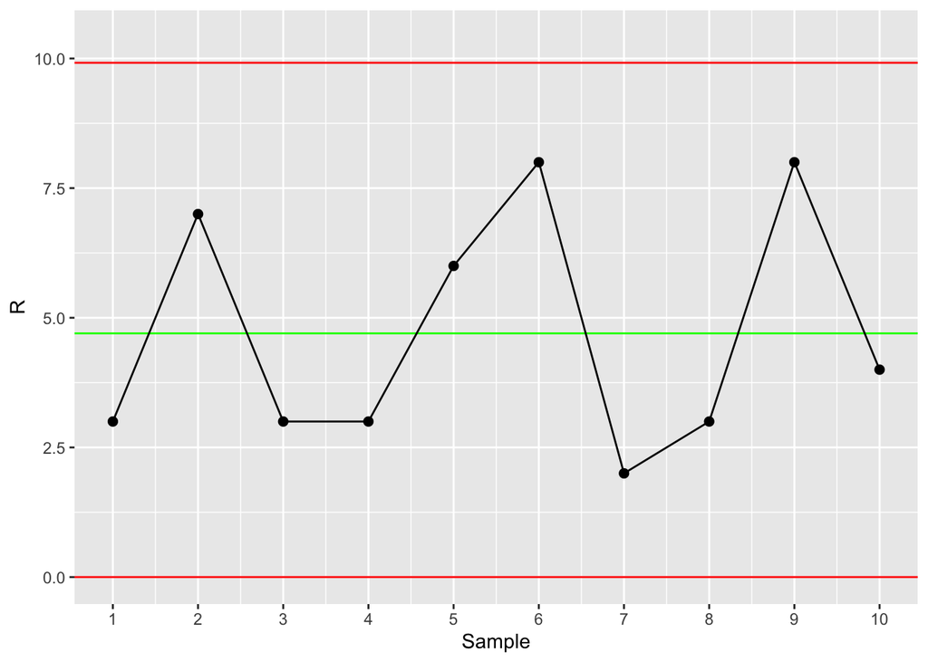

```r
dt %>%
  ggplot() +
  geom_hline(yintercept = R, color = "green") +
  geom_hline(yintercept = RLCL, color = "red") +
  geom_hline(yintercept = RUCL, color = "red") +
  geom_line(aes(x = Sample, y = R)) +
  geom_point(aes(x = Sample, y = R), size = 2) +
  scale_x_continuous("Sample", 1:nrow(dt)) +
  ylim(c(RLCL - (RLCL * .05), RUCL * 1.05))
```

```r
if(min(dt$R) > RLCL & max(dt$R) < RUCL) {
  writeLines("The process is in control in terms of the variation")
} else {
  writeLines("The process is not in control in terms of the variation")
}
```

```
## The process is in control in terms of the variation
```

## G

> Find the process standard deviation ($\sigma$)

```r
writeLines(paste("The standard deviation is:", sigma <- (R / valueTable$d2)))
```

```
## The standard deviation is: 2.01716738197425
```

## H

> Find the appropriate process capability index for the process if the lower and upper specification limits are 8 to 20.

```r
LSL <- 8
USL <- 20
if((LSL + USL) / 2 == xBar) {
  writeLines("The process is centered")
  C <- (USL - LSL) / (6 * sigma)
} else {
  writeLines("The process is not centered")
  C <- min((USL - xBar) / (3 * sigma),
           (xBar - LSL) / (3 * sigma))
}
```

```
## The process is not centered
```

```r
writeLines(paste("C is:", C))
```

```
## C is: 0.846070921985816
```

## I

> What is your interpretation of the capability index?

```r
if(C < 1) {
  writeLines("Because C is less than one, the process is not capable and process improvement should begin immediately.")
} else {
  writeLines("Because C is greater than one, the process is capabale.")
  if(C < 1.33) {
    writeLines("However, because C is still under 1.33, we should probably improve the process a bit more.")
  }
}
```

```
## Because C is less than one, the process is not capable and process improvement should begin immediately.
```